# act_report

## Act_report - WeRateDogs Data Analysis

## Goal

**To wrangle, analyze and visualize the tweet archive of Twitter user "@dog_rates", also known as WeRateDogs.**

WeRateDogs is a Twitter account that rates people's dogs with a humorous comment about the dog. These ratings almost always have a denominator of 10. The numerators, though? Almost always greater than 10. 11/10, 12/10, 13/10, etc. Why? Because "they're good dogs Brent." WeRateDogs has over 4 million followers and has received international media coverage.

## Storing The Data

- The cleaned master dataset (all 3 datasets merged into 1) was later saved to a CSV file named "twitter_archive_master.csv".

## Data Analysis

- I read the saved CSV file (twitter_archive_master.csv data) into a pandas dataframe called dog_data
- I got insights from the dog_data dataframe

## Questions & Insights

The dog with the highest retweet count has the following details:

- No name
- Is of the Labrador_retriever breed (Algorithim's highest image prediction confidence = 0.82533)
- In its Doggo stage
- Rated 13/10
1. What tweets have the highest favorite_count?
- tweet id: 822872901745569793 has the highest favorite count.

The dog with the highest favourite count has the following details:

- No name
- Is of the Lakeland_terrier breed (Algorithim's highest image prediction confidence = 0.196015)
- In its Puppo stage
- Rated 13/10
1. We have a total number of 1,971 original tweets in our master dataset
1. The average number of likes (favorite count) given to an original tweet is approximately 8,949.11 likes, while the average number of retweets given to an original tweet is approximately 2,784.45 retweets.
1. The minimum number of likes given to an original tweet is 81 likes, while the minimum number of retweets given to an original tweet is 16 retweets.
1. The maximum number of likes given to an original tweet is 132,810 likes, while the maximum number of retweets given to an original tweet is 79,515 retweets.

## Visualizations

**The image of the dog with the highest retweet count**

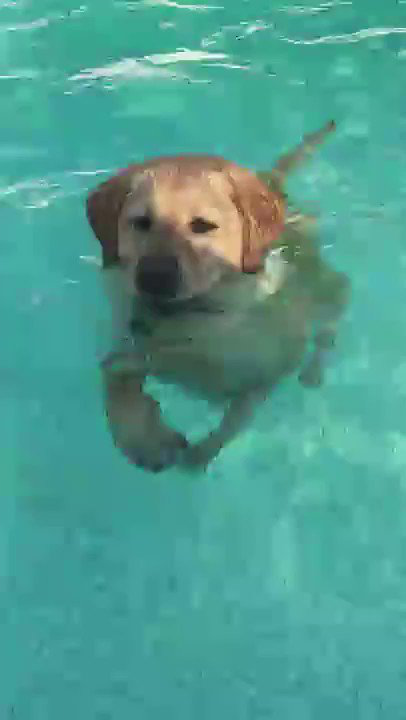

**The dog with the highest retweet count has the following details:**

- No name
- Is of the Labrador_retriever breed (Algorithim's highest image prediction confidence = 0.82533)
- In its Doggo stage
- Rated 13/10

**The dog with the highest favourite count has the following details:**

- No name
- Is of the Lakeland_terrier breed (Algorithim's highest image prediction confidence = 0.196015)
- In its Puppo stage
- Rated 13/10

**1. What is the most occuring image number in our dataset?**

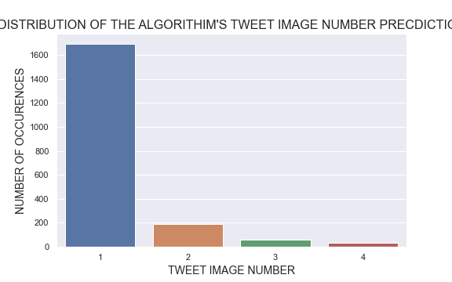

**Image number 1 is the most occuring image number**

**2. What is the most occuring dog stage entry in our dataset?**

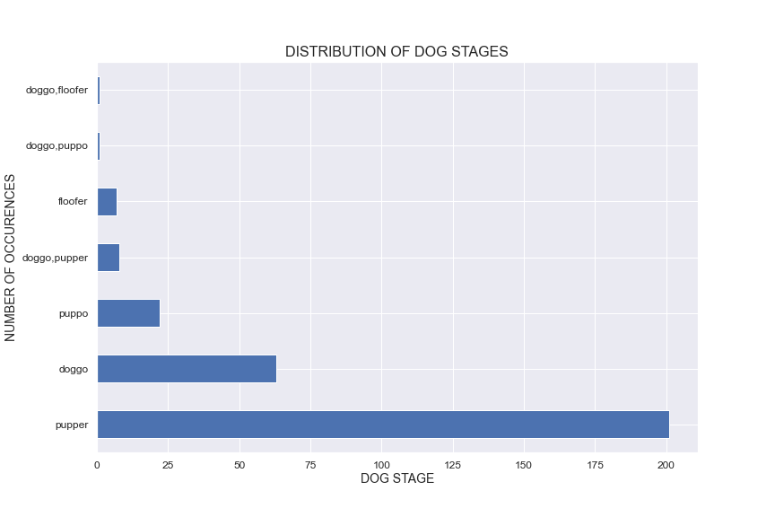

**Pupper is the most occuring dog stage entry.**

**3. What are the top 3 dog stages by retweet_count**

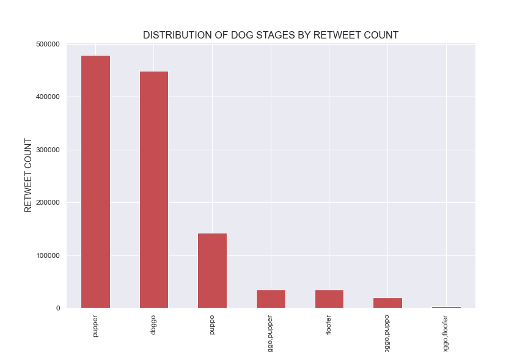

**The top 3 dog stages by retweet count are:**

- Pupper
- Doggo
- Puppo

**4. What are the top 3 dog stages by favourite_count**

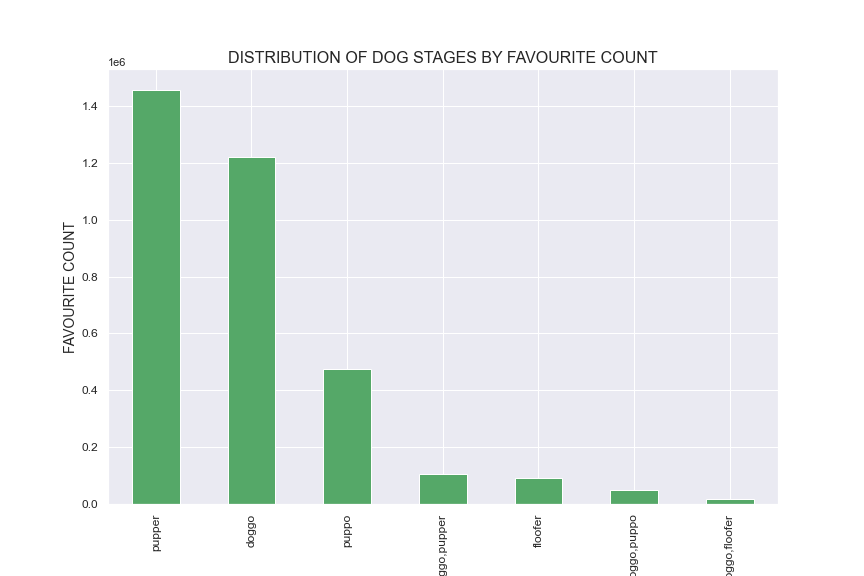

**The top 3 dog stages by favorite count are:**

- Pupper
- Doggo
- Puppo